# Libraries

## Libraries

```r
library(dplyr)
library(ggplot2)
library(lattice)
```

## Loading and preprocessing the data

```
This assignment makes use of data from a personal activity monitoring device. This device collects data at 5 minute intervals through out the day.  The data for this assignment can be downloaded from the course web site, or
```

the GitHub repository also contains the dataset for the assignment so you do not have to download the data separately.:

```
Dataset: [Activity monitoring data](https://d396qusza40orc.cloudfront.net/repdata%2Fdata%2Factivity.zip) (52K)

The variables included in this dataset are:

* steps: Number of steps taking in a 5-minute interval (missing values are coded as NA)

* date: The date on which the measurement was taken in YYYY-MM-DD format

* interval: Identifier for the 5-minute interval in which measurement was taken
```

```r
## Zipped data file is part of forked repository, so don't need to download it
#fileUrl <- "https://d396qusza40orc.cloudfront.net/repdata%2Fdata%2Factivity.zip"
#download.file(fileUrl,destfile="activity.zip",method="curl")

unzip("activity.zip")
df <- read.csv("activity.csv")

message('Original size of data')
```

```
## Original size of data
```

```r
str(df)
```

```
## 'data.frame':    17568 obs. of  3 variables:
##  $ steps   : int  NA NA NA NA NA NA NA NA NA NA ...
##  $ date    : Factor w/ 61 levels "2012-10-01","2012-10-02",..: 1 1 1 1 1 1 1 1 1 1 ...
##  $ interval: int  0 5 10 15 20 25 30 35 40 45 ...
```

```r
#get rid of NaNs
df_clean <- df[complete.cases(df), ]

message('Cleaned size of data')
```

```
## Cleaned size of data
```

```r
str(df_clean)
```

```
## 'data.frame':    15264 obs. of  3 variables:
##  $ steps   : int  0 0 0 0 0 0 0 0 0 0 ...
##  $ date    : Factor w/ 61 levels "2012-10-01","2012-10-02",..: 2 2 2 2 2 2 2 2 2 2 ...
##  $ interval: int  0 5 10 15 20 25 30 35 40 45 ...
```

## Latex's definition of mean(x), because I want to see that Latex works.

The arithmetic mean is equal to \(\frac{1}{n} \sum_{i=1}^{n} x_{i}\).

## What is mean total number of steps taken per day?

For this part of the assignment, you can ignore the missing values in the dataset.

```
* Make a histogram of the total number of steps taken each day

* Calculate and report the mean and median total number of steps taken per day
```

```r
df$date <- as.POSIXct(df$date)   # convert sytle of date

df_clean  %>%  group_by(date) %>%
            summarise(totSteps=sum(steps)) -> df_byDates

ymax = max(df_byDates$totSteps)
```

Now for the plot.

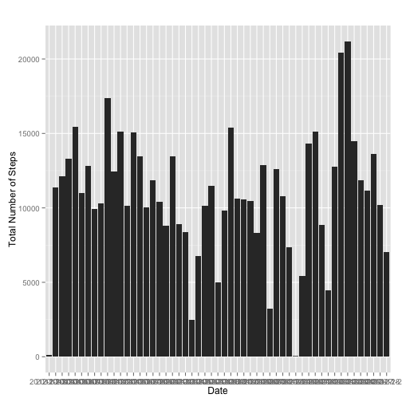

```r
   # echo=TRUE breaks the plot. Error in R markdown.

qplot(date, totSteps, data=df_byDates,
    geom = "histogram",
    stat="identity",
    xlab="Date", ylab="Total Number of Steps",
    ylim = c(0, ymax),
    main="")
```

- Mean number of steps per day is 1.0766189 × 10<sup>4</sup>.
- Median number of steps per day is 10765.

## What is the average daily activity pattern?

[output not shown]

```r
df_clean  %>%  summarise(meanSteps=mean(steps)) -> interval_mean

df_clean  %>%  group_by(interval) %>%
            summarize(meanSteps=mean(steps)) -> df_byIntervals
df_clean  %>%  group_by(interval) %>%
            summarize(maxSteps=max(steps)) -> df_maxByIntervals


whichMax <- which.max( df_maxByIntervals$maxSteps )  # index of the max
```

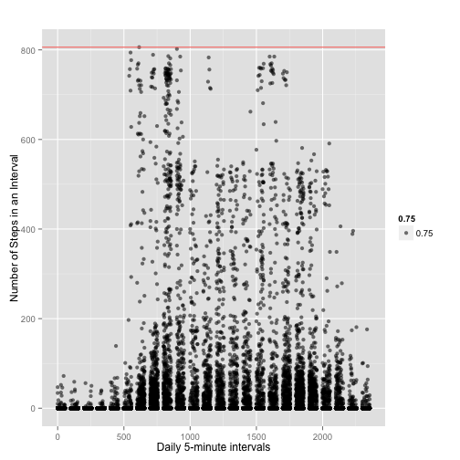

```r
qplot( interval, steps, data=df_clean,
    alpha = 0.75,
    type = 'l',   # line type
    xlab="Daily 5-minute intervals", ylab="Number of Steps in an Interval",
    # ylim = c(0, ymax),
    main="") +
    geom_hline(aes(yintercept=df_maxByIntervals$maxSteps[whichMax],
                        color="orange"))
```

## Imputing missing values

[output not shown]

*I calculate the number of rows with missing values (NA) as 2304 out of 17568 original rows*, which is 13.1147541%.

As for a strategy to fill up missing data, it is generally A BAD IDEA! It is extrapolation, at best. One might put in FAKE data based on what you might expect to find, say the average value, or a low baseline like times of low activity. Low activity might be occasional squirming while sleeping which might get recorded as a few steps, or recordings while watching a movie. Which (average or baseline) is a better might depend on what time of day the missing records are. Actually, if one is good at Bayesian analysis, I would bet that the baseline would be a good choice of prior and that the missing data can just be ignored. So to be contrarian, *I chose to use the average from midnight to 5 AM to (under protest) fill up the missing data.*

```r
df_clean %>%  summarise(meanSteps=mean(steps[interval<500])) ->
    steps_baseline

df_clean %>%  summarise(meanSteps=mean(steps)) ->
    steps_mean

# get number from data frame wrapper.
meanNight <- steps_baseline$meanSteps[1]
mean24hr <- steps_mean$meanSteps[1]


df -> df_impute
# replace NA's with value steps_baseline
df_impute$steps[is.na(df_impute$steps)] <- meanNight
```

*I replace the missing values with a value of 0.658805* This corresponds to a mean number of steps per interval between midnight and 5 AM (500 on the graph's x axis) of 0.658805, compared to an overall mean of 37.3825996. Only 2/3's of a step per interval during the nighttime hours. Very small!

```r
df_impute  %>%  group_by(date) %>%
            summarise(totSteps=sum(steps)) -> df_imputeByDates
```

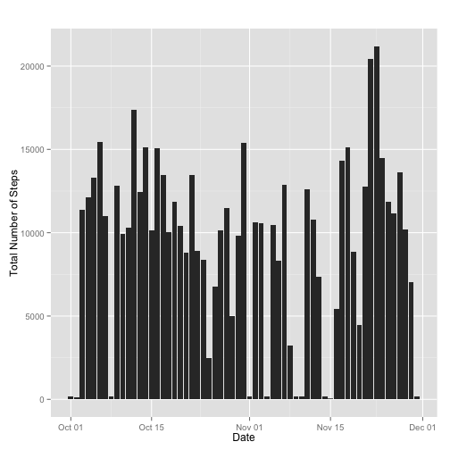

```r
qplot(date, totSteps, data=df_imputeByDates,
    geom = "histogram",
    stat="identity",
    xlab="Date", ylab="Total Number of Steps",
    ylim = c(0, ymax),
    main="")
```

```r
mean_percentChange <- 100*
    (mean(df_imputeByDates$totSteps) - mean(df_byDates$totSteps)) /
    mean(df_byDates$totSteps)

median_percentChange <- 100*
    (median(df_imputeByDates$totSteps) - median(df_byDates$totSteps)) /
    median(df_byDates$totSteps)
```

- Imputed data: Mean number of steps per day is 9379.1128982; cleaned, unimputed mean was 1.0766189 × 10<sup>4</sup>. By filling missing data, the mean has changed by -12.8836288 percent.
- Imputed data: Median number of steps per day is 1.0395 × 10<sup>4</sup>; cleaned, unimputed median was 10765. By filling missing data, the median has changed by -3.4370646 percent.

Note: Since I filled missing data with a low estimate, the changes in the mean and median are probably exaggerated compared to using the mean or median for the filling value.

## Are there differences in activity patterns between weekdays and weekends?

[output not shown]

```r
weekwhat <- weekdays(as.Date(df_impute$date))
df_impute$weekCat <- factor(rep(NA, length(nrow(df_impute)) ),
                 levels=c("weekday", "weekend") )
df_impute$weekCat[ weekwhat %in% c("Saturday", "Sunday")] <- "weekend"
df_impute$weekCat[ is.na(df_impute$weekCat) ] <- "weekday"

df_impute  %>%  group_by(interval, weekCat) %>%
             summarize(meanSteps=mean(steps)) -> df_imputebyIntervals
```

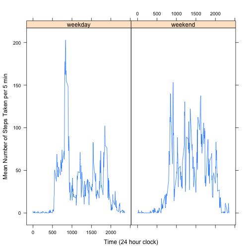

```r
xyplot(
    df_imputebyIntervals$meanSteps ~ df_imputebyIntervals$interval |df_imputebyIntervals$weekCat,
    type = 'l',   # line? type
    xlab = 'Time (24 hour clock)',
    ylab = 'Mean Number of Steps Taken per 5 min'
    )
```